# RQ3: Can we accurately estimate energy consumption before training DL models for image classification?

Santiago del Rey

## Load data

```r
df <- read_parquet("data/metrics/processed/clean-dl-training-energy-consumption-dataset.gzip") %>%
  rename(
    energy = `energy (MJ)`,
    power_draw = `average gpu power (W)`,
    training_duration = `training duration (h)`,
    used_ram = `average ram used (MB)`,
    batch_size = `batch size`,
    image_size = `image size`,
    allocated_ram = `total ram (GB)`,
    training_environment = `training environment`,
    start_time = `start time`,
  ) %>%
  filter(architecture == "inception_v3") %>%
  mutate(
    energy_per_image = (energy * 1000000) / `total seen images`, # Convert MJ to J and normalize by total seen images
    epoch_duration = training_duration / `trained epochs` * 3600, # Calculate average epoch duration in seconds
    batch_size = factor(batch_size, levels = c("32", "64", "256")),
    input_size = case_match(
      image_size,
      "(75, 75)" ~ "75x75",
      "(128, 128)" ~ "128x128",
      "(224, 224)" ~ "224x224"
    ),
    input_size = factor(input_size, levels = c("75x75", "128x128", "224x224"), ordered = TRUE),
    allocated_ram = factor(allocated_ram, levels = c("8", "16", "24", "32")),
    # Convert to a factor after renaming; case_match() returns a character vector
    dataset = case_match(
      dataset,
      "stanford_dogs" ~ "Stanford Dogs",
      "caltech101" ~ "Caltech 101"
    ),
    dataset = factor(dataset, levels = c("Caltech 101", "Stanford Dogs"))
  ) %>%
  select(energy_per_image, power_draw, epoch_duration, used_ram, batch_size, input_size, dataset, training_environment, allocated_ram, start_time)

# Set sum-to-zero contrasts in each model call so that tests do not depend on global options
factor_contrasts <- list(batch_size = "contr.sum", input_size = "contr.sum", dataset = "contr.sum")
```

## Visualize the data

### Data summary

```r
df_batch_input <- df %>%
  filter(training_environment == "Desktop ML Engineer" & dataset != "ChessLive") %>%
  group_by(batch_size, input_size, dataset) %>%
  mutate(
    Q1 = quantile(energy_per_image, 0.25),
    Q3 = quantile(energy_per_image, 0.75),
    IQR = Q3 - Q1,
    is_outlier = energy_per_image < (Q1 - 1.5 * IQR) | energy_per_image > (Q3 + 1.5 * IQR)
  ) %>%
  ungroup() %>%
  filter(!is_outlier) %>%
  select(-Q1, -Q3, -IQR, -is_outlier)

df_batch_input %>%
  group_by(batch_size, input_size, dataset) %>%
  get_summary_stats(energy_per_image, type = "mean_sd")
```

| batch_size | input_size | dataset | variable | n | mean | sd |
| --- | --- | --- | --- | --- | --- | --- |
| 32 | 75x75 | Caltech 101 | energy_per_image | 29 | 0.033 | 0.000 |
| 32 | 75x75 | Stanford Dogs | energy_per_image | 30 | 0.035 | 0.000 |
| 32 | 128x128 | Caltech 101 | energy_per_image | 30 | 0.073 | 0.000 |
| 32 | 128x128 | Stanford Dogs | energy_per_image | 31 | 0.079 | 0.001 |
| 32 | 224x224 | Caltech 101 | energy_per_image | 30 | 0.235 | 0.002 |
| 32 | 224x224 | Stanford Dogs | energy_per_image | 29 | 0.263 | 0.001 |
| 64 | 75x75 | Caltech 101 | energy_per_image | 31 | 0.024 | 0.000 |
| 64 | 75x75 | Stanford Dogs | energy_per_image | 30 | 0.025 | 0.000 |
| 64 | 128x128 | Caltech 101 | energy_per_image | 31 | 0.060 | 0.000 |
| 64 | 128x128 | Stanford Dogs | energy_per_image | 30 | 0.063 | 0.000 |

[output cut: 8 more lines]

```r
df_allocated_ram_energy <- df %>%
  filter(batch_size == "256" & input_size == "128x128" & dataset == "Stanford Dogs" & training_environment == "Server") %>%
  group_by(allocated_ram) %>%
  mutate(
    Q1 = quantile(energy_per_image, 0.25),
    Q3 = quantile(energy_per_image, 0.75),
    IQR = Q3 - Q1,
    is_outlier = energy_per_image < (Q1 - 1.5 * IQR) | energy_per_image > (Q3 + 1.5 * IQR)
  ) %>%
  ungroup() %>%
  filter(!is_outlier) %>%
  select(-Q1, -Q3, -IQR, -is_outlier)

df_allocated_ram_energy %>%
  group_by(allocated_ram) %>%
  get_summary_stats(energy_per_image, type = "mean_sd")
```

| allocated_ram | variable | n | mean | sd |
| --- | --- | --- | --- | --- |
| 8 | energy_per_image | 30 | 0.056 | 0.000 |
| 16 | energy_per_image | 21 | 0.055 | 0.001 |
| 24 | energy_per_image | 30 | 0.055 | 0.000 |
| 32 | energy_per_image | 29 | 0.056 | 0.000 |

```r
df_allocated_ram_time <- df %>%
  filter(batch_size == "256" & input_size == "128x128" & dataset == "Stanford Dogs" & training_environment == "Server") %>%
  group_by(allocated_ram) %>%
  mutate(
    Q1 = quantile(epoch_duration, 0.25),
    Q3 = quantile(epoch_duration, 0.75),
    IQR = Q3 - Q1,
    is_outlier = epoch_duration < (Q1 - 1.5 * IQR) | epoch_duration > (Q3 + 1.5 * IQR)
  ) %>%
  ungroup() %>%
  filter(!is_outlier) %>%
  select(-Q1, -Q3, -IQR, -is_outlier)
df_allocated_ram_time %>%
  group_by(allocated_ram) %>%
  get_summary_stats(epoch_duration, type = "mean_sd")
```

| allocated_ram | variable | n | mean | sd |
| --- | --- | --- | --- | --- |
| 8 | epoch_duration | 30 | 4.173 | 0.031 |
| 16 | epoch_duration | 21 | 3.989 | 0.089 |
| 24 | epoch_duration | 29 | 3.926 | 0.019 |
| 32 | epoch_duration | 28 | 4.061 | 0.030 |

```r
df_allocated_ram_ram <- df %>%
  filter(batch_size == "256" & input_size == "128x128" & dataset == "Stanford Dogs" & training_environment == "Server") %>%
  group_by(allocated_ram) %>%
  mutate(
    Q1 = quantile(used_ram, 0.25),
    Q3 = quantile(used_ram, 0.75),
    IQR = Q3 - Q1,
    is_outlier = used_ram < (Q1 - 1.5 * IQR) | used_ram > (Q3 + 1.5 * IQR)
  ) %>%
  ungroup() %>%
  filter(!is_outlier) %>%
  select(-Q1, -Q3, -IQR, -is_outlier)
df_allocated_ram_ram %>%
  group_by(allocated_ram) %>%
  get_summary_stats(used_ram, type = "mean_sd")
```

| allocated_ram | variable | n | mean | sd |
| --- | --- | --- | --- | --- |
| 8 | used_ram | 30 | 7831.916 | 95.480 |
| 16 | used_ram | 21 | 8197.920 | 93.201 |
| 24 | used_ram | 30 | 8681.279 | 29.449 |
| 32 | used_ram | 27 | 8686.433 | 17.392 |

### Boxplot of energy consumption

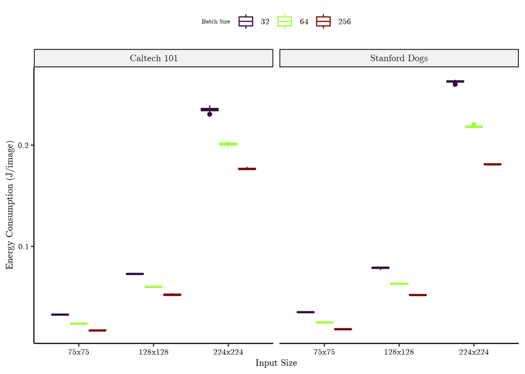

```r
energy_boxplot <- ggplot(df_batch_input, aes(x = input_size, y = energy_per_image, color = batch_size)) +
  geom_boxplot() +
  facet_wrap(~dataset) +
  labs(
    x = "Input Size",
    y = "Energy Consumption (J/image)",
    color = "Batch Size"
  )

plot(energy_boxplot)
```

```r
ggsave(
  energy_boxplot + pub_theme,
  filename = file.path(fig_dir, "batch-and-input-size-effect-energy.pdf"),
  device = cairo_pdf,
  units = "cm",
  width = 13.71, height = 8, dpi = 300
)
```

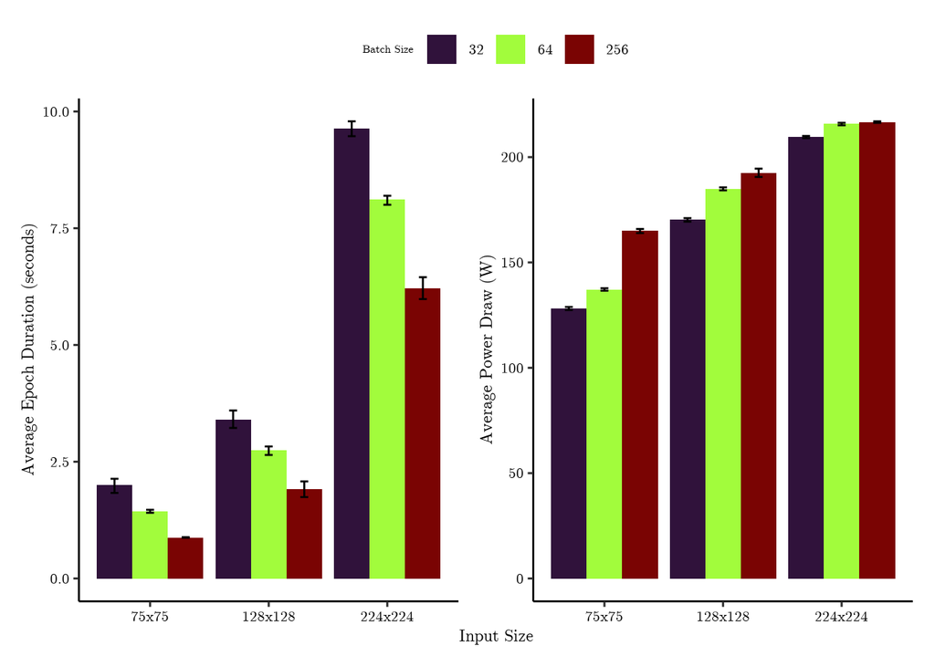

```r
tmp_df <- df_batch_input %>%
  filter(dataset == "Caltech 101")

training_duration_barplot <- ggplot(tmp_df, aes(x = input_size, y = epoch_duration, fill = batch_size)) +
  geom_bar(stat = "summary", fun = "mean", position = "dodge") +
  geom_errorbar(
    stat = "summary",
    fun.data = mean_cl_boot,
    position = position_dodge(width = 0.9),
    width = 0.2
  ) +
  labs(
    x = "Input Size",
    y = "Average Epoch Duration (seconds)",
    fill = "Batch Size"
  )

power_draw_barplot <- ggplot(tmp_df, aes(x = input_size, y = power_draw, fill = batch_size)) +
  geom_bar(stat = "summary", fun = "mean", position = "dodge") +
  geom_errorbar(
    stat = "summary",
    fun.data = mean_cl_boot,
    position = position_dodge(width = 0.9),
    width = 0.2
  ) +
  labs(
    x = "Input Size",
    y = "Average Power Draw (W)",
    fill = "Batch Size"
  )

training_power_plot <- (training_duration_barplot | power_draw_barplot) +
  plot_layout(axes = "collect", guides = "collect")

plot(training_power_plot)
```

```r
ggsave(
  filename = file.path(fig_dir, "batch-and-input-size-effect-power-and-time.pdf"),
  plot = training_power_plot & pub_theme,
  device = cairo_pdf,
  units = "cm",
  width = 13.71, height = 8, dpi = 300
)
```

### Boxplot of epoch duration

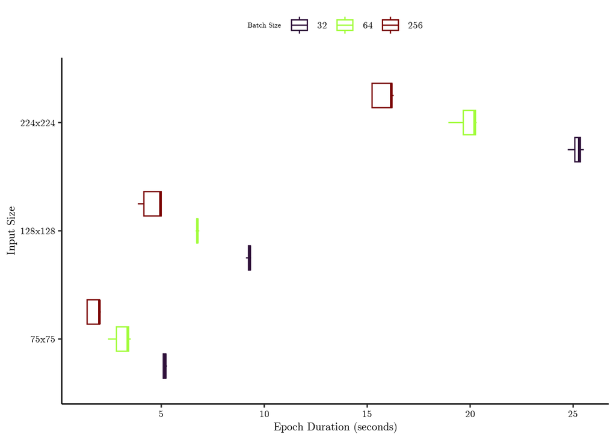

```r
epoch_duration_boxplot <- ggplot(df_batch_input %>% filter(dataset == "Stanford Dogs"), aes(x = input_size, y = epoch_duration, color = batch_size)) +
  geom_boxplot(outliers = FALSE) +
  labs(
    x = "Input Size",
    y = "Epoch Duration (seconds)",
    color = "Batch Size"
  ) +
  coord_flip()

plot(epoch_duration_boxplot)
```

```r
epoch_duration_boxplot <- epoch_duration_boxplot + pub_theme
ggsave(
  filename = file.path(fig_dir, "epoch-time-boxplot-cloud-stanford-dogs.pdf"),
  device = cairo_pdf,
  units = "cm",
  width = 13.71, height = 8, dpi = 300
)
```

### Boxplots of allocated RAM effects

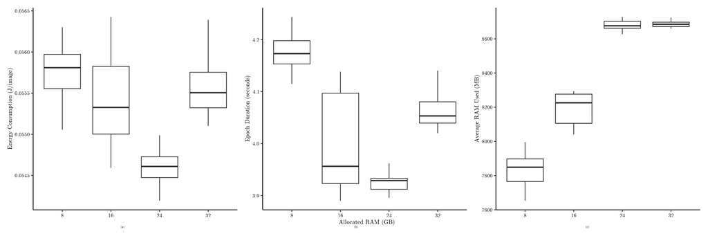

```r
allocated_ram_energy <- ggplot(df_allocated_ram_energy, aes(x = allocated_ram, y = energy_per_image)) +
  geom_boxplot() +
  labs(
    x = "Allocated RAM (GB)",
    y = "Energy Consumption (J/image)"
  )

allocated_ram_time <- ggplot(df_allocated_ram_time, aes(x = allocated_ram, y = epoch_duration)) +
  geom_boxplot() +
  labs(
    x = "Allocated RAM (GB)",
    y = "Epoch Duration (seconds)"
  )

allocated_ram_ram <- ggplot(df_allocated_ram_ram, aes(x = allocated_ram, y = used_ram)) +
  geom_boxplot() +
  labs(
    x = "Allocated RAM (GB)",
    y = "Average RAM Used (MB)"
  )

ram_impact_plot <- (allocated_ram_energy | allocated_ram_time | allocated_ram_ram) +
  plot_layout(axes = "collect") +
  plot_annotation(
    tag_levels = "a",
    tag_prefix = "(",
    tag_suffix = ")",
  ) &
  theme(
    plot.tag.position = "bottom",
    plot.tag = element_text(size = 10),
  )
ram_impact_plot
```

```r
ram_impact_plot <- ram_impact_plot & pub_theme

ggsave(
  filename = file.path(fig_dir, "ram-impact.pdf"),
  plot = ram_impact_plot,
  device = cairo_pdf,
  units = "cm",
  width = 13.71, height = 8, dpi = 300
)
```

## Statistical analysis of the effects of batch size, input size, and dataset on energy consumption

### Linear model with dataset as a fixed effect

```r
model_lm <- lm(energy_per_image ~ batch_size * input_size * dataset, data = df_batch_input, contrasts = factor_contrasts)
summary(model_lm)
```

```
##
## Call:
## lm(formula = energy_per_image ~ batch_size * input_size * dataset,
##     data = df_batch_input, contrasts = factor_contrasts)
##
## Residuals:
##        Min         1Q     Median         3Q        Max
## -0.0045252 -0.0002914  0.0000192  0.0003280  0.0044603
##
## Coefficients:
##                                    Estimate Std. Error   t value Pr(>|t|)
## (Intercept)                       1.002e-01  3.625e-05  2765.515  < 2e-16 ***
## batch_size1                       1.921e-02  5.110e-05   375.976  < 2e-16 ***
## batch_size2                      -1.792e-03  5.128e-05   -34.950  < 2e-16 ***
## input_size1                      -7.510e-02  5.103e-05 -1471.493  < 2e-16 ***
## input_size2                      -3.712e-02  5.096e-05  -728.420  < 2e-16 ***
## dataset1                         -3.495e-03  3.625e-05   -96.405  < 2e-16 ***
## batch_size1:input_size1          -1.064e-02  7.220e-05  -147.394  < 2e-16 ***
## batch_size2:input_size1           8.502e-04  7.204e-05    11.802  < 2e-16 ***
## batch_size1:input_size2          -6.581e-03  7.185e-05   -91.591  < 2e-16 ***
## batch_size2:input_size2           2.144e-04  7.198e-05     2.978  0.00304 **
## batch_size1:dataset1             -2.519e-03  5.110e-05   -49.288  < 2e-16 ***
## batch_size2:dataset1             -8.085e-05  5.128e-05    -1.577  0.11551
## input_size1:dataset1              2.667e-03  5.103e-05    52.260  < 2e-16 ***
## input_size2:dataset1              2.069e-03  5.096e-05    40.603  < 2e-16 ***
## batch_size1:input_size1:dataset1  2.125e-03  7.220e-05    29.435  < 2e-16 ***
## batch_size2:input_size1:dataset1  3.135e-04  7.204e-05     4.352 1.63e-05 ***
## batch_size1:input_size2:dataset1  9.721e-04  7.185e-05    13.529  < 2e-16 ***
## batch_size2:input_size2:dataset1  2.390e-05  7.198e-05     0.332  0.74001
## ---
## Signif. codes:  0 '***' 0.001 '**' 0.01 '*' 0.05 '.' 0.1 ' ' 1
##
## Residual standard error: 0.0008344 on 513 degrees of freedom
## Multiple R-squared:  0.9999, Adjusted R-squared:  0.9999
## F-statistic: 3.042e+05 on 17 and 513 DF,  p-value: < 2.2e-16
```

#### Check assumptions of the linear model

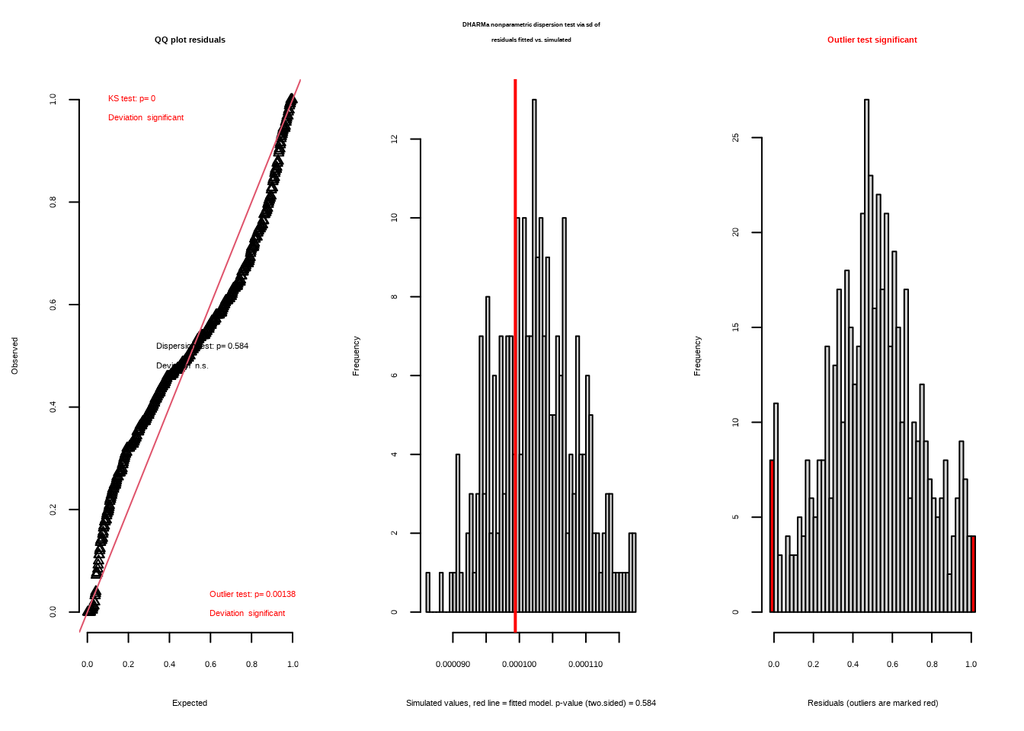

```
## $uniformity
##
##  Asymptotic one-sample Kolmogorov-Smirnov test
##
## data:  simulationOutput$scaledResiduals
## D = 0.12791, p-value = 5.689e-08
## alternative hypothesis: two-sided
##
##
## $dispersion
##
##  DHARMa nonparametric dispersion test via sd of residuals fitted vs.
##  simulated
##
## data:  simulationOutput
## dispersion = 0.96805, p-value = 0.584
## alternative hypothesis: two.sided
##
##
## $outliers
##
##  DHARMa outlier test based on exact binomial test with approximate
##  expectations
##
## data:  simulationOutput
## outliers at both margin(s) = 12, observations = 531, p-value = 0.001384
## alternative hypothesis: true probability of success is not equal to 0.007968127
## 95 percent confidence interval:
##  0.01173041 0.03914269
## sample estimates:
## frequency of outliers (expected: 0.00796812749003984 )
##                                             0.02259887
```

```r
sim_res <- simulateResiduals(model_lm)
testResiduals(sim_res)
```

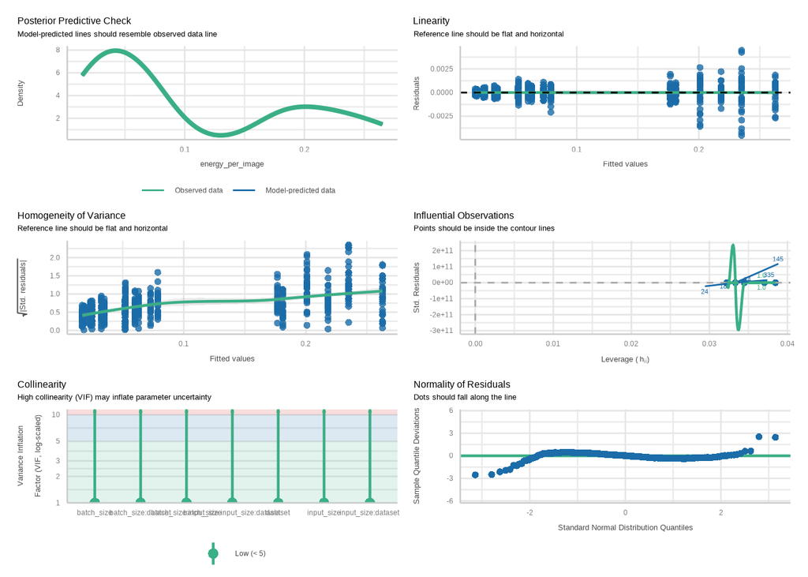

```r
check_model(model_lm)
```

### Linear mixed model

```r
model_lmm <- lmer(
  energy_per_image ~ batch_size * input_size + (1 | dataset),
  data = df_batch_input,
  contrasts = factor_contrasts[c("batch_size", "input_size")]
)
summary(model_lmm)
```

```
## Linear mixed model fit by REML. t-tests use Satterthwaite's method [
## lmerModLmerTest]
## Formula: energy_per_image ~ batch_size * input_size + (1 | dataset)
##    Data: df_batch_input
##
## REML criterion at convergence: -4102.8
##
## Scaled residuals:
##     Min      1Q  Median      3Q     Max
## -3.2771 -0.5922  0.0128  0.5915  2.7612
##
## Random effects:
##  Groups   Name        Variance  Std.Dev.
##  dataset  (Intercept) 2.354e-05 0.004852
##  Residual             2.031e-05 0.004507
## Number of obs: 531, groups:  dataset, 2
##
## Fixed effects:
##                           Estimate Std. Error         df  t value Pr(>|t|)
## (Intercept)              1.002e-01  3.436e-03  1.000e+00   29.156   0.0218 *
## batch_size1              1.920e-02  2.760e-04  5.210e+02   69.573  < 2e-16 ***
## batch_size2             -1.802e-03  2.769e-04  5.210e+02   -6.506 1.81e-10 ***
## input_size1             -7.506e-02  2.756e-04  5.210e+02 -272.385  < 2e-16 ***
## input_size2             -3.707e-02  2.752e-04  5.210e+02 -134.718  < 2e-16 ***
## batch_size1:input_size1 -1.064e-02  3.899e-04  5.210e+02  -27.283  < 2e-16 ***
## batch_size2:input_size1  9.334e-04  3.890e-04  5.210e+02    2.400   0.0168 *
## batch_size1:input_size2 -6.562e-03  3.880e-04  5.210e+02  -16.912  < 2e-16 ***
## batch_size2:input_size2  2.677e-04  3.887e-04  5.210e+02    0.689   0.4914
## ---
## Signif. codes:  0 '***' 0.001 '**' 0.01 '*' 0.05 '.' 0.1 ' ' 1
##
## Correlation of Fixed Effects:
##             (Intr) btch_1 btch_2 inpt_1 inpt_2 b_1:_1 b_2:_1 b_1:_2
## batch_size1  0.000
## batch_size2  0.000 -0.496
## input_size1 -0.001  0.015 -0.009
## input_size2 -0.001  0.001 -0.006 -0.484
## btch_sz1:_1  0.001 -0.002  0.002  0.001 -0.006
## btch_sz2:_1  0.000  0.002 -0.019 -0.005  0.010 -0.498
## btch_sz1:_2  0.000 -0.016  0.012 -0.006 -0.008 -0.490  0.241
## btch_sz2:_2  0.000  0.012 -0.021  0.010 -0.004  0.240 -0.479 -0.494
```

```r
Anova(model_lmm, type = 3) # Type III ANOVA for mixed models
```

|  | Chisq | Df | Pr(>Chisq) |
| --- | --- | --- | --- |
| (Intercept) | 850.0858 | 1 | 6.964938e-187 |
| batch_size | 5879.7304 | 2 | 0.000000e+00 |
| input_size | 167097.0558 | 2 | 0.000000e+00 |
| batch_size:input_size | 2421.1314 | 4 | 0.000000e+00 |

#### Check assumptions of the linear mixed model

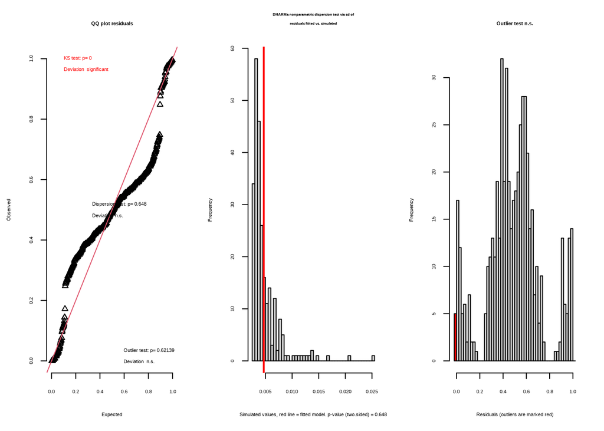

```
## $uniformity
##
##  Asymptotic one-sample Kolmogorov-Smirnov test
##
## data:  simulationOutput$scaledResiduals
## D = 0.17616, p-value = 9.74e-15
## alternative hypothesis: two-sided
##
##
## $dispersion
##
##  DHARMa nonparametric dispersion test via sd of residuals fitted vs.
##  simulated
##
## data:  simulationOutput
## dispersion = 0.96952, p-value = 0.648
## alternative hypothesis: two.sided
##
##
## $outliers
##
##  DHARMa outlier test based on exact binomial test with approximate
##  expectations
##
## data:  simulationOutput
## outliers at both margin(s) = 5, observations = 531, p-value = 0.6214
## alternative hypothesis: true probability of success is not equal to 0.007968127
## 95 percent confidence interval:
##  0.003064282 0.021836567
## sample estimates:
## frequency of outliers (expected: 0.00796812749003984 )
##                                            0.009416196
```

```r
sim_res_lmm <- simulateResiduals(model_lmm)
testResiduals(sim_res_lmm)
```

### Generalized linear model with Gamma distribution

```r
model_glm <- glm(
  energy_per_image ~ batch_size * input_size * dataset,
  data = df_batch_input,
  family = Gamma(link = "log"),
  contrasts = factor_contrasts
)
summary(model_glm)
```

```
##
## Call:
## glm(formula = energy_per_image ~ batch_size * input_size * dataset,
##     family = Gamma(link = "log"), data = df_batch_input, contrasts = factor_contrasts)
##
## Coefficients:
##                                    Estimate Std. Error   t value Pr(>|t|)
## (Intercept)                      -2.6841569  0.0003733 -7190.199  < 2e-16 ***
## batch_size1                       0.2296722  0.0005263   436.424  < 2e-16 ***
## batch_size2                      -0.0067972  0.0005281   -12.870  < 2e-16 ***
## input_size1                      -1.0346467  0.0005256 -1968.653  < 2e-16 ***
## input_size2                      -0.0906068  0.0005248  -172.646  < 2e-16 ***
## dataset1                         -0.0297836  0.0003733   -79.783  < 2e-16 ***
## batch_size1:input_size1           0.0988989  0.0007436   133.003  < 2e-16 ***
## batch_size2:input_size1           0.0043206  0.0007418     5.824 1.01e-08 ***
## batch_size1:input_size2          -0.0358797  0.0007400   -48.487  < 2e-16 ***
## batch_size2:input_size2          -0.0066502  0.0007413    -8.971  < 2e-16 ***
## batch_size1:dataset1             -0.0139363  0.0005263   -26.482  < 2e-16 ***
## batch_size2:dataset1             -0.0002012  0.0005281    -0.381    0.703
## input_size1:dataset1             -0.0031757  0.0005256    -6.043 2.92e-09 ***
## input_size2:dataset1              0.0098106  0.0005248    18.694  < 2e-16 ***
## batch_size1:input_size1:dataset1  0.0106756  0.0007436    14.357  < 2e-16 ***
## batch_size2:input_size1:dataset1  0.0085820  0.0007418    11.568  < 2e-16 ***
## batch_size1:input_size2:dataset1 -0.0053405  0.0007400    -7.217 1.92e-12 ***
## batch_size2:input_size2:dataset1 -0.0039150  0.0007413    -5.281 1.90e-07 ***
## ---
## Signif. codes:  0 '***' 0.001 '**' 0.01 '*' 0.05 '.' 0.1 ' ' 1
##
## (Dispersion parameter for Gamma family taken to be 7.384722e-05)
##
##     Null deviance: 408.049206  on 530  degrees of freedom
## Residual deviance:   0.037907  on 513  degrees of freedom
## AIC: -6397.2
##
## Number of Fisher Scoring iterations: 3
```

```r
Anova(model_glm, type = 3, test.statistic = "Wald") # Type III Wald chi-square tests (sum-to-zero contrasts)
```

|  | Df | Chisq | Pr(>Chisq) |
| --- | --- | --- | --- |
| (Intercept) | 1 | 5.169895e+07 | 0.000000e+00 |
| batch_size | 2 | 2.453864e+05 | 0.000000e+00 |
| input_size | 2 | 5.531764e+06 | 0.000000e+00 |
| dataset | 1 | 6.365331e+03 | 0.000000e+00 |
| batch_size:input_size | 4 | 2.497713e+04 | 0.000000e+00 |
| batch_size:dataset | 2 | 9.433446e+02 | 1.429948e-205 |
| input_size:dataset | 2 | 3.612822e+02 | 3.536389e-79 |
| batch_size:input_size:dataset | 4 | 6.718670e+02 | 4.300095e-144 |

#### Check assumptions of the generalized linear model

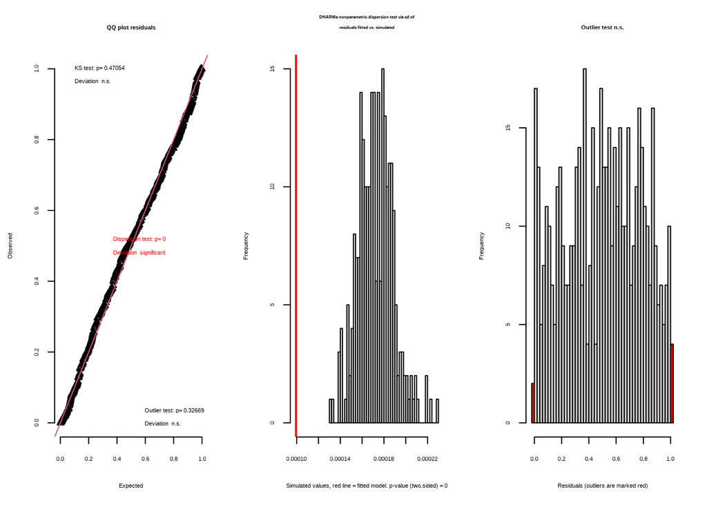

```
## $uniformity
##
##  Asymptotic one-sample Kolmogorov-Smirnov test
##
## data:  simulationOutput$scaledResiduals
## D = 0.036738, p-value = 0.4705
## alternative hypothesis: two-sided
##
##
## $dispersion
##
##  DHARMa nonparametric dispersion test via sd of residuals fitted vs.
##  simulated
##
## data:  simulationOutput
## dispersion = 0.57578, p-value < 2.2e-16
## alternative hypothesis: two.sided
##
##
## $outliers
##
##  DHARMa outlier test based on exact binomial test with approximate
##  expectations
##
## data:  simulationOutput
## outliers at both margin(s) = 6, observations = 531, p-value = 0.3267
## alternative hypothesis: true probability of success is not equal to 0.007968127
## 95 percent confidence interval:
##  0.00415767 0.02443093
## sample estimates:
## frequency of outliers (expected: 0.00796812749003984 )
##                                             0.01129944
```

```r
sim_res_glm <- simulateResiduals(model_glm)
testResiduals(sim_res_glm)
```

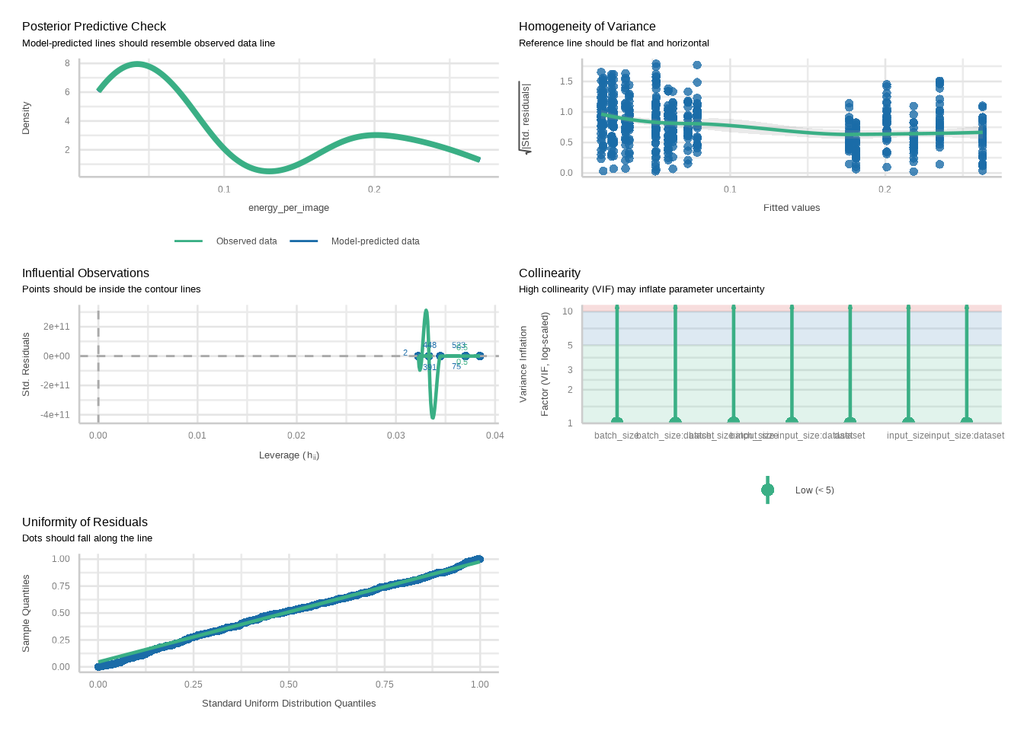

```r
check_model(model_glm)
```

### Compare models

```r
compare_performance(model_lm, model_lmm, model_glm, rank = TRUE)
```

```
## Following indices with missing values are not used for ranking: R2,
##   R2_adjusted, R2_conditional, R2_marginal, ICC, R2_Nagelkerke
```

| Name | Model | RMSE | Sigma | R2 | R2_adjusted | R2_conditional | R2_marginal | ICC | R2_Nagelkerke | AIC_wt | AICc_wt | BIC_wt | Performance_Score |
| --- | --- | --- | --- | --- | --- | --- | --- | --- | --- | --- | --- | --- | --- |
| model_glm | glm | 0.0008201835 | 0.0085934406 | NA | NA | NA | NA | NA | 0.9999383 | 1.000000e+00 | 1.000000e+00 | 1.000000e+00 | 0.8000000 |
| model_lm | lm | 0.0008201835 | 0.0008344487 | 0.9999008 | 0.9998975 | NA | NA | NA | NA | 1.283232e-86 | 1.283232e-86 | 1.283232e-86 | 0.4000000 |
| model_lmm | lmerModLmerTest | 0.0044645427 | 0.0045071709 | NA | NA | 0.99702 | 0.9935671 | 0.5367643 | NA | 0.000000e+00 | 0.000000e+00 | 0.000000e+00 | 0.1053299 |

### Significance testing and effect size

Type III Wald chi-square tests with sum-to-zero contrasts, consistent with the Type III tests used for the architecture and environment models. The three-way interaction is significant, so each main effect is the effect averaged equally over the levels of the other factors. We use Wald tests because Type III likelihood-ratio (and F) tests refit models without a main effect but with its interactions, and those refits do not converge here. Type II likelihood-ratio tests, which do not depend on the contrasts, are reported as a check.

The statistics are very large because the Gamma dispersion is tiny (the coefficient of variation within each configuration is below 1%), not because observations are replicated: each row is one training run.

```r
anova_results <- Anova(model_glm, type = 3, test.statistic = "Wald") # Type III, Wald chi-square tests
anova_results
```

|  | Df | Chisq | Pr(>Chisq) |
| --- | --- | --- | --- |
| (Intercept) | 1 | 5.169895e+07 | 0.000000e+00 |
| batch_size | 2 | 2.453864e+05 | 0.000000e+00 |
| input_size | 2 | 5.531764e+06 | 0.000000e+00 |
| dataset | 1 | 6.365331e+03 | 0.000000e+00 |
| batch_size:input_size | 4 | 2.497713e+04 | 0.000000e+00 |
| batch_size:dataset | 2 | 9.433446e+02 | 1.429948e-205 |
| input_size:dataset | 2 | 3.612822e+02 | 3.536389e-79 |
| batch_size:input_size:dataset | 4 | 6.718670e+02 | 4.300095e-144 |

```r
Anova(model_glm, type = 2) # Check: Type II, likelihood-ratio chi-square tests
```

|  | LR Chisq | Df | Pr(>Chisq) |
| --- | --- | --- | --- |
| batch_size | 245638.0659 | 2 | 0.000000e+00 |
| input_size | 5311280.0175 | 2 | 0.000000e+00 |
| dataset | 6381.3676 | 1 | 0.000000e+00 |
| batch_size:input_size | 24810.7742 | 4 | 0.000000e+00 |
| batch_size:dataset | 928.8771 | 2 | 1.981054e-202 |
| input_size:dataset | 358.6207 | 2 | 1.338172e-78 |
| batch_size:input_size:dataset | 671.7174 | 4 | 4.633060e-144 |

```r
cat("Dispersion:", summary(model_glm)$dispersion, " residual df:", df.residual(model_glm), "\n")
```

```
## Dispersion: 7.384722e-05  residual df: 513
```

```r
non_significant_terms <- anova_results %>%
  filter(rownames(.) != "(Intercept)" & `Pr(>Chisq)` > 0.05)
```

```r
knitr::asis_output("### Non-significant terms")
non_significant_terms
```

Because the model uses a log link, effects are multiplicative. We report them as ratios of mean energy per image (fold changes) with 95% confidence intervals.

```r
emm_input <- emmeans(model_glm, ~ input_size | batch_size * dataset, type = "response")
input_ratios <- contrast(emm_input, method = "revpairwise", type = "response")
confint(input_ratios, adjust = "none")
```

|  | contrast | batch_size | dataset | ratio | SE | df | lower.CL | upper.CL |
| --- | --- | --- | --- | --- | --- | --- | --- | --- |
| 1 | 128x128 / 75x75 | 32 | Caltech 101 | 2.239453 | 0.005011588 | 513 | 2.229629 | 2.249320 |
| 2 | 224x224 / 75x75 | 32 | Caltech 101 | 7.231976 | 0.016184171 | 513 | 7.200251 | 7.263842 |
| 3 | 224x224 / 128x128 | 32 | Caltech 101 | 3.229350 | 0.007165336 | 513 | 3.215303 | 3.243457 |
| 4 | 128x128 / 75x75 | 64 | Caltech 101 | 2.543544 | 0.005551886 | 513 | 2.532660 | 2.554475 |
| 5 | 224x224 / 75x75 | 64 | Caltech 101 | 8.509653 | 0.018891859 | 513 | 8.472619 | 8.546849 |
| 6 | 224x224 / 128x128 | 64 | Caltech 101 | 3.345589 | 0.007427376 | 513 | 3.331029 | 3.360212 |
| 7 | 128x128 / 75x75 | 256 | Caltech 101 | 3.099648 | 0.006995125 | 513 | 3.085936 | 3.113421 |
| 8 | 224x224 / 75x75 | 256 | Caltech 101 | 10.481481 | 0.023654061 | 513 | 10.435113 | 10.528054 |
| 9 | 224x224 / 128x128 | 256 | Caltech 101 | 3.381506 | 0.007631208 | 513 | 3.366547 | 3.396532 |
| 10 | 128x128 / 75x75 | 32 | Stanford Dogs | 2.253064 | 0.004958657 | 513 | 2.243343 | 2.262827 |

[output cut: 8 more lines]

```r
emm_batch <- emmeans(model_glm, ~ batch_size | input_size * dataset, type = "response")
batch_ratios <- contrast(emm_batch, method = "revpairwise", type = "response")
confint(batch_ratios, adjust = "none")
```

|  | contrast | input_size | dataset | ratio | SE | df | lower.CL | upper.CL |
| --- | --- | --- | --- | --- | --- | --- | --- | --- |
| 1 | batch_size64 / batch_size32 | 75x75 | Caltech 101 | 0.7265803 | 0.001613045 | 513 | 0.7234182 | 0.7297562 |
| 2 | batch_size256 / batch_size32 | 75x75 | Caltech 101 | 0.5186505 | 0.001170464 | 513 | 0.5163561 | 0.5209551 |
| 3 | batch_size256 / batch_size64 | 75x75 | Caltech 101 | 0.7138241 | 0.001584726 | 513 | 0.7107176 | 0.7169443 |
| 4 | batch_size64 / batch_size32 | 128x128 | Caltech 101 | 0.8252414 | 0.001816233 | 513 | 0.8216809 | 0.8288173 |
| 5 | batch_size256 / batch_size32 | 128x128 | Caltech 101 | 0.7178692 | 0.001606493 | 513 | 0.7147200 | 0.7210323 |
| 6 | batch_size256 / batch_size64 | 128x128 | Caltech 101 | 0.8698900 | 0.001931200 | 513 | 0.8661043 | 0.8736923 |
| 7 | batch_size64 / batch_size32 | 224x224 | Caltech 101 | 0.8549455 | 0.001913251 | 513 | 0.8511950 | 0.8587126 |
| 8 | batch_size256 / batch_size32 | 224x224 | Caltech 101 | 0.7516929 | 0.001682186 | 513 | 0.7483954 | 0.7550050 |
| 9 | batch_size256 / batch_size64 | 224x224 | Caltech 101 | 0.8792290 | 0.001984198 | 513 | 0.8753395 | 0.8831358 |
| 10 | batch_size64 / batch_size32 | 75x75 | Stanford Dogs | 0.7098587 | 0.001575046 | 513 | 0.7067711 | 0.7129598 |

[output cut: 8 more lines]

```r
# Marginal fold change from 75x75 to 224x224, averaged over batch sizes and datasets
confint(contrast(emmeans(model_glm, ~input_size, type = "response"), method = "revpairwise", type = "response"), adjust = "none")
```

```
## NOTE: Results may be misleading due to involvement in interactions
```

|  | contrast | ratio | SE | df | lower.CL | upper.CL |
| --- | --- | --- | --- | --- | --- | --- |
| 1 | 128x128 / 75x75 | 2.570344 | 0.002325807 | 513 | 2.565779 | 2.574918 |
| 2 | 224x224 / 75x75 | 8.670273 | 0.007974858 | 513 | 8.654620 | 8.685955 |
| 3 | 224x224 / 128x128 | 3.373195 | 0.003098315 | 513 | 3.367114 | 3.379287 |

### Post hoc tests

Estimate marginal means for the interaction between batch size and input size, conditioned on the dataset.

```r
emm_lm <- emmeans(model_glm, ~ batch_size * input_size * dataset, type = "response")
emm_lm
```

```
##  batch_size input_size dataset       response       SE  df lower.CL upper.CL
##  32         75x75      Caltech 101    0.03250 5.19e-05 513  0.03240  0.03260
##  64         75x75      Caltech 101    0.02362 3.64e-05 513  0.02354  0.02369
##  256        75x75      Caltech 101    0.01686 2.69e-05 513  0.01680  0.01691
##  32         128x128    Caltech 101    0.07279 1.14e-04 513  0.07256  0.07301
##  64         128x128    Caltech 101    0.06007 9.27e-05 513  0.05988  0.06025
##  256        128x128    Caltech 101    0.05225 8.34e-05 513  0.05209  0.05242
##  32         224x224    Caltech 101    0.23505 3.69e-04 513  0.23433  0.23578
##  64         224x224    Caltech 101    0.20096 3.21e-04 513  0.20033  0.20159
##  256        224x224    Caltech 101    0.17669 2.82e-04 513  0.17614  0.17724
##  32         75x75      Stanford Dogs  0.03494 5.48e-05 513  0.03484  0.03505
##  64         75x75      Stanford Dogs  0.02481 3.89e-05 513  0.02473  0.02488
##  256        75x75      Stanford Dogs  0.01819 2.81e-05 513  0.01814  0.01825
##  32         128x128    Stanford Dogs  0.07873 1.22e-04 513  0.07849  0.07897
##  64         128x128    Stanford Dogs  0.06303 9.89e-05 513  0.06284  0.06323
##  256        128x128    Stanford Dogs  0.05190 8.14e-05 513  0.05174  0.05206
##  32         224x224    Stanford Dogs  0.26275 4.19e-04 513  0.26193  0.26357
##  64         224x224    Stanford Dogs  0.21826 3.68e-04 513  0.21754  0.21898
##  256        224x224    Stanford Dogs  0.18108 2.99e-04 513  0.18049  0.18167
##
## Confidence level used: 0.95
## Intervals are back-transformed from the log scale
```

#### Calculate pairwise comparisons with Tukey adjustment

```r
pairwise_emm <- pairs(emm_lm, by = "dataset", adjust = "tukey")

pairwise_emm
```

```
## dataset = Caltech 101:
##  contrast                                        ratio       SE  df null
##  batch_size32 75x75 / batch_size64 75x75       1.37631 0.003060 513    1
##  batch_size32 75x75 / batch_size256 75x75      1.92808 0.004350 513    1
##  batch_size32 75x75 / batch_size32 128x128     0.44654 0.000999 513    1
##  batch_size32 75x75 / batch_size64 128x128     0.54110 0.001200 513    1
##  batch_size32 75x75 / batch_size256 128x128    0.62203 0.001400 513    1
##  batch_size32 75x75 / batch_size32 224x224     0.13827 0.000309 513    1
##  batch_size32 75x75 / batch_size64 224x224     0.16174 0.000365 513    1
##  batch_size32 75x75 / batch_size256 224x224    0.18395 0.000415 513    1
##  batch_size64 75x75 / batch_size256 75x75      1.40091 0.003110 513    1
##  batch_size64 75x75 / batch_size32 128x128     0.32445 0.000714 513    1
##  batch_size64 75x75 / batch_size64 128x128     0.39315 0.000858 513    1
##  batch_size64 75x75 / batch_size256 128x128    0.45196 0.001000 513    1
##  batch_size64 75x75 / batch_size32 224x224     0.10047 0.000221 513    1
##  batch_size64 75x75 / batch_size64 224x224     0.11751 0.000261 513    1
##  batch_size64 75x75 / batch_size256 224x224    0.13366 0.000297 513    1
##  batch_size256 75x75 / batch_size32 128x128    0.23160 0.000518 513    1
##  batch_size256 75x75 / batch_size64 128x128    0.28064 0.000623 513    1
##  batch_size256 75x75 / batch_size256 128x128   0.32262 0.000728 513    1
##  batch_size256 75x75 / batch_size32 224x224    0.07172 0.000160 513    1
##  batch_size256 75x75 / batch_size64 224x224    0.08388 0.000189 513    1
##  batch_size256 75x75 / batch_size256 224x224   0.09541 0.000215 513    1
##  batch_size32 128x128 / batch_size64 128x128   1.21177 0.002670 513    1
##  batch_size32 128x128 / batch_size256 128x128  1.39301 0.003120 513    1
##  batch_size32 128x128 / batch_size32 224x224   0.30966 0.000687 513    1
##  batch_size32 128x128 / batch_size64 224x224   0.36220 0.000811 513    1
##  batch_size32 128x128 / batch_size256 224x224  0.41195 0.000922 513    1
##  batch_size64 128x128 / batch_size256 128x128  1.14957 0.002550 513    1
##  batch_size64 128x128 / batch_size32 224x224   0.25554 0.000562 513    1
##  batch_size64 128x128 / batch_size64 224x224   0.29890 0.000664 513    1
##  batch_size64 128x128 / batch_size256 224x224  0.33996 0.000755 513    1
##  batch_size256 128x128 / batch_size32 224x224  0.22230 0.000497 513    1
##  batch_size256 128x128 / batch_size64 224x224  0.26001 0.000587 513    1
##  batch_size256 128x128 / batch_size256 224x224 0.29573 0.000667 513    1
##  batch_size32 224x224 / batch_size64 224x224   1.16967 0.002620 513    1
##  batch_size32 224x224 / batch_size256 224x224  1.33033 0.002980 513    1
##  batch_size64 224x224 / batch_size256 224x224  1.13736 0.002570 513    1
##    t.ratio p.value
##    143.873  <.0001
```

[output cut: 99 more lines]

```
##   -446.178  <.0001
##   -368.197  <.0001
##     87.617  <.0001
##   -637.913  <.0001
##   -539.412  <.0001
##   -462.934  <.0001
##   -724.784  <.0001
##   -623.843  <.0001
##   -548.214  <.0001
##     79.935  <.0001
##    161.977  <.0001
##     79.080  <.0001
##
## P value adjustment: tukey method for comparing a family of 9 estimates
## Tests are performed on the log scale
```

```r
non_significant_pairs <- as.data.frame(pairwise_emm) %>%
  filter(p.value > 0.05)
```

```r
knitr::asis_output("### Non-significant pairwise comparisons")
non_significant_pairs
```

#### Plot the estimated marginal means.

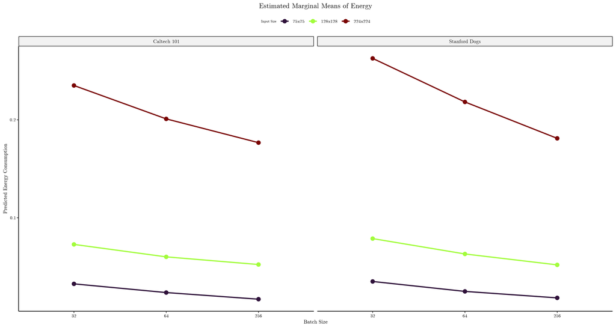

```r
emm_df <- as.data.frame(emm_lm) %>%
  filter(!is.na(response))

ggplot(emm_df, aes(x = batch_size, y = response, group = input_size, color = input_size)) +
  geom_line(linewidth = 1) +
  geom_point(size = 3) +
  facet_wrap(~dataset) +
  labs(
    title = "Estimated Marginal Means of Energy",
    x = "Batch Size",
    y = "Predicted Energy Consumption",
    color = "Input Size"
  )
```

## Statistical analysis of the effects of allocated RAM on energy consumption

Each allocated-RAM level was run in a separate session, and the 16 GB runs come from the batch- and input-size experiment on the Server. The RAM level is therefore confounded with the session (date), and the differences below may partly reflect session effects. The effect is also non-monotonic, so we compare all levels pairwise rather than describing a trend.

```r
df %>%
  filter(batch_size == "256" & input_size == "128x128" & dataset == "Stanford Dogs" & training_environment == "Server") %>%
  group_by(allocated_ram) %>%
  summarise(runs = n(), first_run = min(start_time), last_run = max(start_time))
```

| allocated_ram | runs | first_run | last_run |
| --- | --- | --- | --- |
| 8 | 30 | 2024-01-02 12:57:44.750000 | 2024-01-02 19:56:40.073999 |
| 16 | 21 | 2023-12-16 05:06:29.416999 | 2023-12-21 09:24:45.921000 |
| 24 | 30 | 2024-01-02 21:08:14.240999 | 2024-01-03 03:35:43.271000 |
| 32 | 30 | 2024-03-13 12:48:06.769999 | 2024-03-13 19:23:32.915999 |

### Linear model with allocated RAM as a fixed effect

```r
model_lm_ram <- lm(energy_per_image ~ allocated_ram, data = df_allocated_ram_energy)
summary(model_lm_ram)
```

```
##
## Call:
## lm(formula = energy_per_image ~ allocated_ram, data = df_allocated_ram_energy)
##
## Residuals:
##        Min         1Q     Median         3Q        Max
## -8.793e-04 -2.290e-04 -2.286e-05  1.810e-04  9.560e-04
##
## Coefficients:
##                   Estimate Std. Error t value Pr(>|t|)
## (Intercept)      5.577e-02  6.444e-05 865.446  < 2e-16 ***
## allocated_ram16 -3.000e-04  1.004e-04  -2.988  0.00349 **
## allocated_ram24 -1.177e-03  9.113e-05 -12.919  < 2e-16 ***
## allocated_ram32 -2.038e-04  9.191e-05  -2.217  0.02875 *
## ---
## Signif. codes:  0 '***' 0.001 '**' 0.01 '*' 0.05 '.' 0.1 ' ' 1
##
## Residual standard error: 0.000353 on 106 degrees of freedom
## Multiple R-squared:  0.6464, Adjusted R-squared:  0.6364
## F-statistic: 64.59 on 3 and 106 DF,  p-value: < 2.2e-16
```

#### Check assumptions of the linear model with allocated RAM

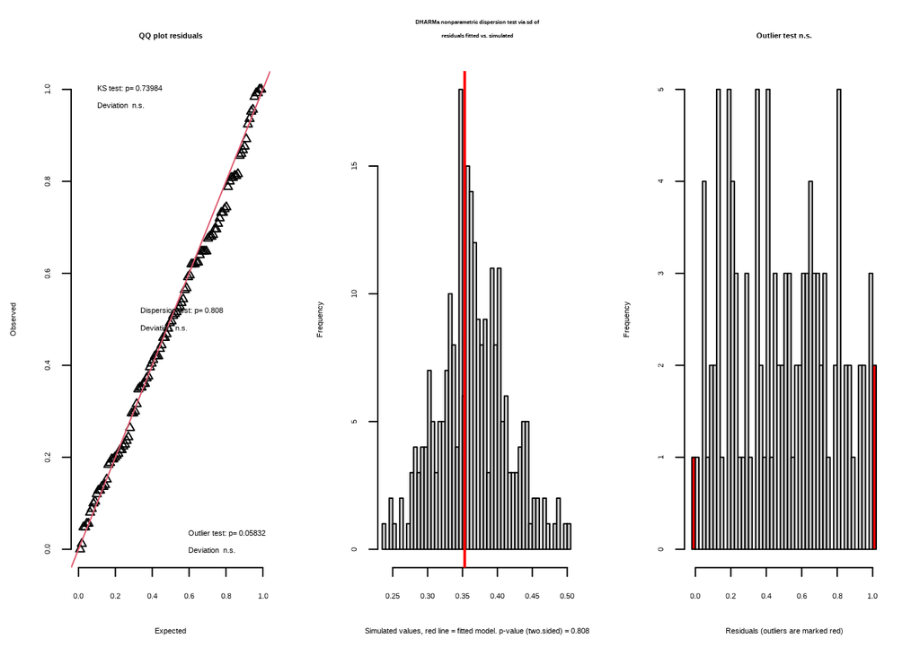

```
## $uniformity
##
##  Asymptotic one-sample Kolmogorov-Smirnov test
##
## data:  simulationOutput$scaledResiduals
## D = 0.065091, p-value = 0.7398
## alternative hypothesis: two-sided
##
##
## $dispersion
##
##  DHARMa nonparametric dispersion test via sd of residuals fitted vs.
##  simulated
##
## data:  simulationOutput
## dispersion = 0.96892, p-value = 0.808
## alternative hypothesis: two.sided
##
##
## $outliers
##
##  DHARMa outlier test based on exact binomial test with approximate
##  expectations
##
## data:  simulationOutput
## outliers at both margin(s) = 3, observations = 110, p-value = 0.05832
## alternative hypothesis: true probability of success is not equal to 0.007968127
## 95 percent confidence interval:
##  0.005659996 0.077636770
## sample estimates:
## frequency of outliers (expected: 0.00796812749003984 )
##                                             0.02727273
```

```r
sim_res_ram <- simulateResiduals(model_lm_ram)
testResiduals(sim_res_ram)
```

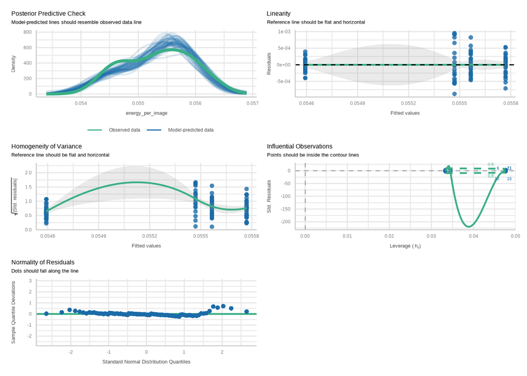

```r
check_model(model_lm_ram)
```

#### Significance testing and effect size

```r
Anova(model_lm_ram) # One-way ANOVA (with a single factor, Types I-III coincide)
```

|  | Sum Sq | Df | F value | Pr(>F) |
| --- | --- | --- | --- | --- |
| allocated_ram | 2.414017e-05 | 3 | 64.59316 | 7.866707e-24 |
| Residuals | 1.320500e-05 | 106 | NA | NA |

```r
eta_squared(model_lm_ram, partial = FALSE) # Calculate eta squared for effect sizes
```

| Parameter | Eta2 | CI | CI_low | CI_high |
| --- | --- | --- | --- | --- |
| allocated_ram | 0.6464068 | 0.95 | 0.5568011 | 1 |

```r
# Variances differ between RAM levels, so we also report Welch's ANOVA and Games-Howell comparisons
leveneTest(energy_per_image ~ allocated_ram, data = df_allocated_ram_energy)
```

|  | Df | F value | Pr(>F) |
| --- | --- | --- | --- |
| group | 3 | 8.094849 | 6.627587e-05 |
|  | 106 | NA | NA |

```r
oneway.test(energy_per_image ~ allocated_ram, data = df_allocated_ram_energy, var.equal = FALSE)
```

```
##
##  One-way analysis of means (not assuming equal variances)
##
## data:  energy_per_image and allocated_ram
## F = 135.89, num df = 3.000, denom df = 51.519, p-value < 2.2e-16
```

```r
rstatix::games_howell_test(df_allocated_ram_energy, energy_per_image ~ allocated_ram)
```

|  | .y. | group1 | group2 | estimate | conf.low | conf.high | p.adj | p.adj.signif |
| --- | --- | --- | --- | --- | --- | --- | --- | --- |
| 1 | energy_per_image | 8 | 16 | -0.0003000200 | -0.0006708616 | 7.082160e-05 | 1.45e-01 | ns |
| 2 | energy_per_image | 8 | 24 | -0.0011773268 | -0.0013511830 | -1.003471e-03 | 0.00e+00 | **** |
| 3 | energy_per_image | 8 | 32 | -0.0002037912 | -0.0004204461 | 1.286371e-05 | 7.20e-02 | ns |
| 4 | energy_per_image | 16 | 24 | -0.0008773068 | -0.0012346391 | -5.199746e-04 | 3.36e-06 | **** |
| 5 | energy_per_image | 16 | 32 | 0.0000962288 | -0.0002801835 | 4.726411e-04 | 8.98e-01 | ns |
| 6 | energy_per_image | 24 | 32 | 0.0009735356 | 0.0007854643 | 1.161607e-03 | 0.00e+00 | **** |

#### Post hoc tests for allocated RAM

```r
emm_ram <- emmeans(model_lm_ram, ~allocated_ram)
emm_ram
```

```
##  allocated_ram  emmean       SE  df lower.CL upper.CL
##  8             0.05577 6.44e-05 106  0.05564  0.05590
##  16            0.05547 7.70e-05 106  0.05532  0.05562
##  24            0.05459 6.44e-05 106  0.05446  0.05472
##  32            0.05557 6.55e-05 106  0.05544  0.05570
##
## Confidence level used: 0.95
```

```r
pairs(emm_ram, adjust = "tukey")
```

```
##  contrast                           estimate       SE  df t.ratio p.value
##  allocated_ram8 - allocated_ram16   3.00e-04 1.00e-04 106   2.988  0.0181
##  allocated_ram8 - allocated_ram24   1.18e-03 9.11e-05 106  12.919  <.0001
##  allocated_ram8 - allocated_ram32   2.04e-04 9.19e-05 106   2.217  0.1252
##  allocated_ram16 - allocated_ram24  8.77e-04 1.00e-04 106   8.736  <.0001
##  allocated_ram16 - allocated_ram32 -9.62e-05 1.01e-04 106  -0.952  0.7771
##  allocated_ram24 - allocated_ram32 -9.74e-04 9.19e-05 106 -10.592  <.0001
##
## P value adjustment: tukey method for comparing a family of 4 estimates
```

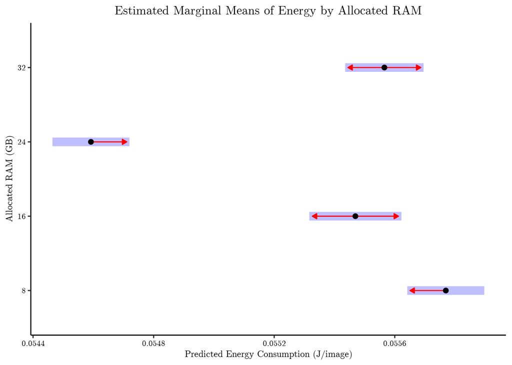

```r
plot(emm_ram, comparisons = TRUE) +
  labs(
    title = "Estimated Marginal Means of Energy by Allocated RAM",
    x = "Predicted Energy Consumption (J/image)",
    y = "Allocated RAM (GB)",
  )
```

## Statistical analysis of the effects of allocated RAM on epoch duration

### Linear model with allocated RAM as a fixed effect

```r
model_lm_duration <- lm(epoch_duration ~ allocated_ram, data = df_allocated_ram_time)
summary(model_lm_duration)
```

```
##
## Call:
## lm(formula = epoch_duration ~ allocated_ram, data = df_allocated_ram_time)
##
## Residuals:
##       Min        1Q    Median        3Q       Max
## -0.099226 -0.024267 -0.006018  0.022046  0.149113
##
## Coefficients:
##                  Estimate Std. Error t value Pr(>|t|)
## (Intercept)      4.173142   0.008429  495.10  < 2e-16 ***
## allocated_ram16 -0.183793   0.013135  -13.99  < 2e-16 ***
## allocated_ram24 -0.246902   0.012023  -20.54  < 2e-16 ***
## allocated_ram32 -0.112217   0.012131   -9.25 3.18e-15 ***
## ---
## Signif. codes:  0 '***' 0.001 '**' 0.01 '*' 0.05 '.' 0.1 ' ' 1
##
## Residual standard error: 0.04617 on 104 degrees of freedom
## Multiple R-squared:  0.8144, Adjusted R-squared:  0.8091
## F-statistic: 152.1 on 3 and 104 DF,  p-value: < 2.2e-16
```

#### Check assumptions of the linear model with allocated RAM

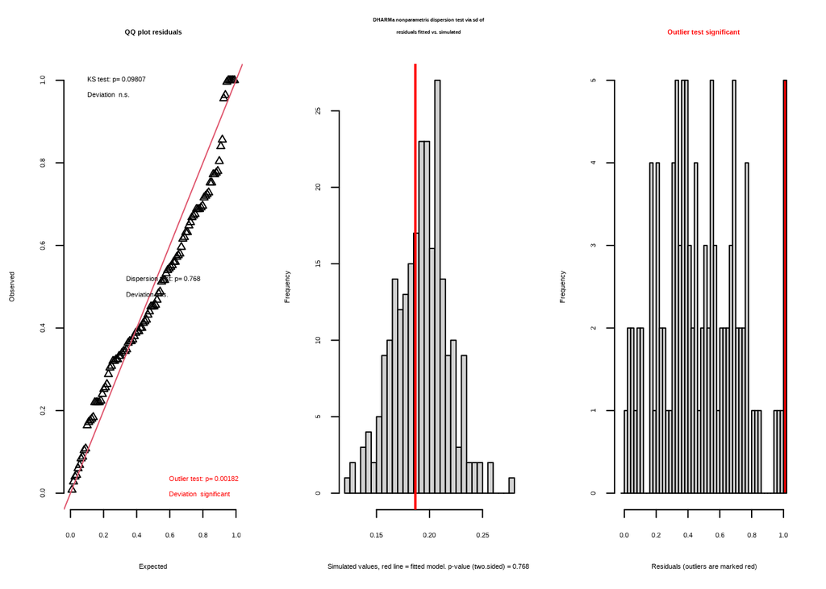

```
## $uniformity
##
##  Asymptotic one-sample Kolmogorov-Smirnov test
##
## data:  simulationOutput$scaledResiduals
## D = 0.11815, p-value = 0.09807
## alternative hypothesis: two-sided
##
##
## $dispersion
##
##  DHARMa nonparametric dispersion test via sd of residuals fitted vs.
##  simulated
##
## data:  simulationOutput
## dispersion = 0.97017, p-value = 0.768
## alternative hypothesis: two.sided
##
##
## $outliers
##
##  DHARMa outlier test based on exact binomial test with approximate
##  expectations
##
## data:  simulationOutput
## outliers at both margin(s) = 5, observations = 108, p-value = 0.001815
## alternative hypothesis: true probability of success is not equal to 0.007968127
## 95 percent confidence interval:
##  0.01520092 0.10473809
## sample estimates:
## frequency of outliers (expected: 0.00796812749003984 )
##                                              0.0462963
```

```r
sim_res_duration <- simulateResiduals(model_lm_duration)
testResiduals(sim_res_duration)
```

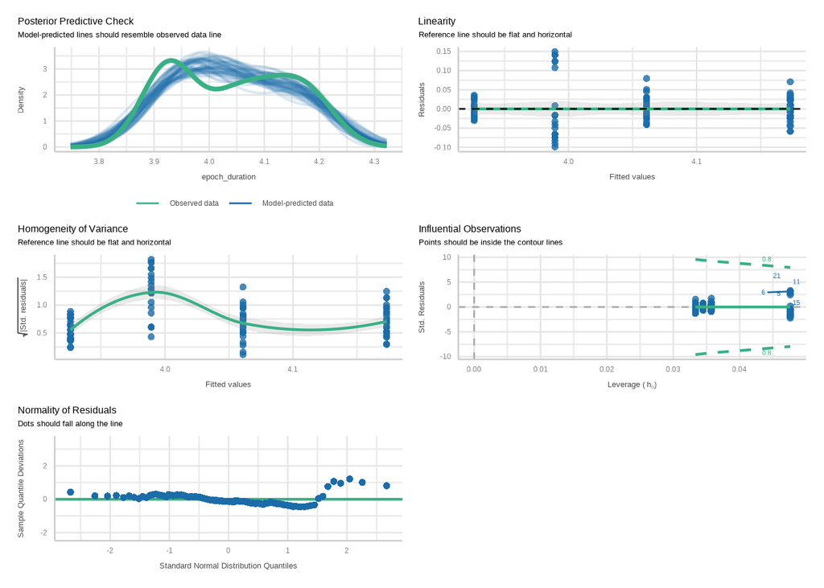

```r
check_model(model_lm_duration)
```

#### Significance testing and effect size

```r
Anova(model_lm_duration) # One-way ANOVA (with a single factor, Types I-III coincide)
```

|  | Sum Sq | Df | F value | Pr(>F) |
| --- | --- | --- | --- | --- |
| allocated_ram | 0.9727986 | 3 | 152.1383 | 6.810127e-38 |
| Residuals | 0.2216647 | 104 | NA | NA |

```r
eta_squared(model_lm_duration, partial = FALSE) # Calculate eta squared for effect sizes
```

| Parameter | Eta2 | CI | CI_low | CI_high |
| --- | --- | --- | --- | --- |
| allocated_ram | 0.8144232 | 0.95 | 0.7638722 | 1 |

```r
leveneTest(epoch_duration ~ allocated_ram, data = df_allocated_ram_time)
```

|  | Df | F value | Pr(>F) |
| --- | --- | --- | --- |
| group | 3 | 13.5665 | 1.547736e-07 |
|  | 104 | NA | NA |

```r
oneway.test(epoch_duration ~ allocated_ram, data = df_allocated_ram_time, var.equal = FALSE)
```

```
##
##  One-way analysis of means (not assuming equal variances)
##
## data:  epoch_duration and allocated_ram
## F = 484.6, num df = 3.000, denom df = 50.171, p-value < 2.2e-16
```

```r
rstatix::games_howell_test(df_allocated_ram_time, epoch_duration ~ allocated_ram)
```

|  | .y. | group1 | group2 | estimate | conf.low | conf.high | p.adj | p.adj.signif |
| --- | --- | --- | --- | --- | --- | --- | --- | --- |
| 1 | epoch_duration | 8 | 16 | -0.18379257 | -0.23990991 | -0.127675244 | 2.41e-08 | **** |
| 2 | epoch_duration | 8 | 24 | -0.24690177 | -0.26457975 | -0.229223785 | 0.00e+00 | **** |
| 3 | epoch_duration | 8 | 32 | -0.11221656 | -0.13342279 | -0.091010333 | 7.02e-12 | **** |
| 4 | epoch_duration | 16 | 24 | -0.06310919 | -0.11826044 | -0.007957945 | 2.10e-02 | * |
| 5 | epoch_duration | 16 | 32 | 0.07157601 | 0.01545293 | 0.127699093 | 9.00e-03 | ** |
| 6 | epoch_duration | 24 | 32 | 0.13468520 | 0.11694862 | 0.152421789 | 2.05e-13 | **** |

#### Post hoc tests for allocated RAM on training duration

```r
emm_duration <- emmeans(model_lm_duration, ~allocated_ram)
emm_duration
```

```
##  allocated_ram emmean      SE  df lower.CL upper.CL
##  8              4.173 0.00843 104    4.156    4.190
##  16             3.989 0.01010 104    3.969    4.009
##  24             3.926 0.00857 104    3.909    3.943
##  32             4.061 0.00872 104    4.044    4.078
##
## Confidence level used: 0.95
```

```r
pairs(emm_duration, adjust = "tukey")
```

```
##  contrast                          estimate     SE  df t.ratio p.value
##  allocated_ram8 - allocated_ram16    0.1838 0.0131 104  13.992  <.0001
##  allocated_ram8 - allocated_ram24    0.2469 0.0120 104  20.536  <.0001
##  allocated_ram8 - allocated_ram32    0.1122 0.0121 104   9.250  <.0001
##  allocated_ram16 - allocated_ram24   0.0631 0.0132 104   4.771  <.0001
##  allocated_ram16 - allocated_ram32  -0.0716 0.0133 104  -5.371  <.0001
##  allocated_ram24 - allocated_ram32  -0.1347 0.0122 104 -11.011  <.0001
##
## P value adjustment: tukey method for comparing a family of 4 estimates
```

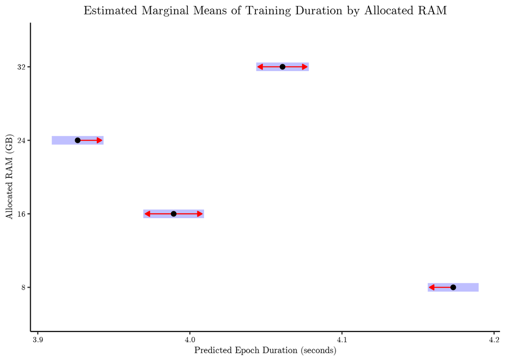

```r
plot(emm_duration, comparisons = TRUE) +
  labs(
    title = "Estimated Marginal Means of Training Duration by Allocated RAM",
    x = "Predicted Epoch Duration (seconds)",
    y = "Allocated RAM (GB)",
  )
```

## Statistical analysis of the effects of allocated RAM on average RAM used

### Linear model with allocated RAM as a fixed effect

```r
model_lm_ram_used <- lm(used_ram ~ allocated_ram, data = df_allocated_ram_ram)
summary(model_lm_ram_used)
```

```
##
## Call:
## lm(formula = used_ram ~ allocated_ram, data = df_allocated_ram_ram)
##
## Residuals:
##     Min      1Q  Median      3Q     Max
## -178.63  -19.80    6.97   37.52  163.91
##
## Coefficients:
##                 Estimate Std. Error t value Pr(>|t|)
## (Intercept)      7831.92      12.29  637.35   <2e-16 ***
## allocated_ram16   366.00      19.15   19.11   <2e-16 ***
## allocated_ram24   849.36      17.38   48.88   <2e-16 ***
## allocated_ram32   854.52      17.85   47.86   <2e-16 ***
## ---
## Signif. codes:  0 '***' 0.001 '**' 0.01 '*' 0.05 '.' 0.1 ' ' 1
##
## Residual standard error: 67.31 on 104 degrees of freedom
## Multiple R-squared:  0.9693, Adjusted R-squared:  0.9684
## F-statistic:  1095 on 3 and 104 DF,  p-value: < 2.2e-16
```

#### Check assumptions of the linear model with allocated RAM

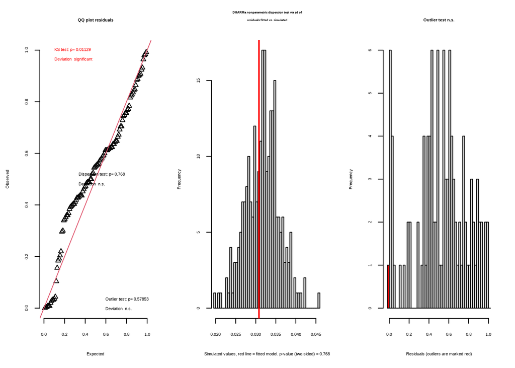

```
## $uniformity
##
##  Asymptotic one-sample Kolmogorov-Smirnov test
##
## data:  simulationOutput$scaledResiduals
## D = 0.15481, p-value = 0.01129
## alternative hypothesis: two-sided
##
##
## $dispersion
##
##  DHARMa nonparametric dispersion test via sd of residuals fitted vs.
##  simulated
##
## data:  simulationOutput
## dispersion = 0.97017, p-value = 0.768
## alternative hypothesis: two.sided
##
##
## $outliers
##
##  DHARMa outlier test based on exact binomial test with approximate
##  expectations
##
## data:  simulationOutput
## outliers at both margin(s) = 1, observations = 108, p-value = 0.5785
## alternative hypothesis: true probability of success is not equal to 0.007968127
## 95 percent confidence interval:
##  0.0002343967 0.0505105337
## sample estimates:
## frequency of outliers (expected: 0.00796812749003984 )
##                                            0.009259259
```

```r
sim_res_ram_used <- simulateResiduals(model_lm_ram_used)
testResiduals(sim_res_ram_used)
```

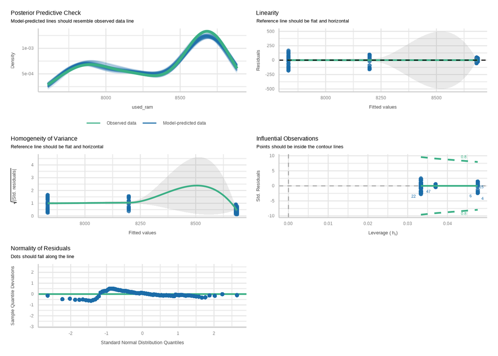

```r
check_model(model_lm_ram_used)
```

#### Significance testing and effect size

```r
Anova(model_lm_ram_used) # One-way ANOVA (with a single factor, Types I-III coincide)
```

|  | Sum Sq | Df | F value | Pr(>F) |
| --- | --- | --- | --- | --- |
| allocated_ram | 14885706.8 | 3 | 1095.337 | 1.668024e-78 |
| Residuals | 471122.3 | 104 | NA | NA |

```r
eta_squared(model_lm_ram_used, partial = FALSE) # Calculate eta squared for effect sizes
```

| Parameter | Eta2 | CI | CI_low | CI_high |
| --- | --- | --- | --- | --- |
| allocated_ram | 0.9693216 | 0.95 | 0.9608279 | 1 |

```r
leveneTest(used_ram ~ allocated_ram, data = df_allocated_ram_ram)
```

|  | Df | F value | Pr(>F) |
| --- | --- | --- | --- |
| group | 3 | 14.91691 | 3.800411e-08 |
|  | 104 | NA | NA |

```r
oneway.test(used_ram ~ allocated_ram, data = df_allocated_ram_ram, var.equal = FALSE)
```

```
##
##  One-way analysis of means (not assuming equal variances)
##
## data:  used_ram and allocated_ram
## F = 923.42, num df = 3.000, denom df = 48.472, p-value < 2.2e-16
```

```r
rstatix::games_howell_test(df_allocated_ram_ram, used_ram ~ allocated_ram)
```

|  | .y. | group1 | group2 | estimate | conf.low | conf.high | p.adj | p.adj.signif |
| --- | --- | --- | --- | --- | --- | --- | --- | --- |
| 1 | used_ram | 8 | 16 | 366.004425 | 294.47482 | 437.53403 | 8.78e-13 | **** |
| 2 | used_ram | 8 | 24 | 849.363428 | 800.12780 | 898.59905 | 0.00e+00 | **** |
| 3 | used_ram | 8 | 32 | 854.517291 | 806.35207 | 902.68251 | 9.73e-14 | **** |
| 4 | used_ram | 16 | 24 | 483.359003 | 425.10799 | 541.61002 | 4.44e-15 | **** |
| 5 | used_ram | 16 | 32 | 488.512866 | 431.08046 | 545.94528 | 3.67e-14 | **** |
| 6 | used_ram | 24 | 32 | 5.153863 | -11.70406 | 22.01178 | 8.48e-01 | ns |

#### Post hoc tests for allocated RAM on average RAM used

```r
emm_ram_used <- emmeans(model_lm_ram_used, ~allocated_ram)
emm_ram_used
```

```
##  allocated_ram emmean   SE  df lower.CL upper.CL
##  8               7832 12.3 104     7808     7856
##  16              8198 14.7 104     8169     8227
##  24              8681 12.3 104     8657     8706
##  32              8686 13.0 104     8661     8712
##
## Confidence level used: 0.95
```

```r
pairs(emm_ram_used, adjust = "tukey")
```

```
##  contrast                          estimate   SE  df t.ratio p.value
##  allocated_ram8 - allocated_ram16   -366.00 19.1 104 -19.113  <.0001
##  allocated_ram8 - allocated_ram24   -849.36 17.4 104 -48.875  <.0001
##  allocated_ram8 - allocated_ram32   -854.52 17.9 104 -47.860  <.0001
##  allocated_ram16 - allocated_ram24  -483.36 19.1 104 -25.241  <.0001
##  allocated_ram16 - allocated_ram32  -488.51 19.6 104 -24.946  <.0001
##  allocated_ram24 - allocated_ram32    -5.15 17.9 104  -0.289  0.9916
##
## P value adjustment: tukey method for comparing a family of 4 estimates
```

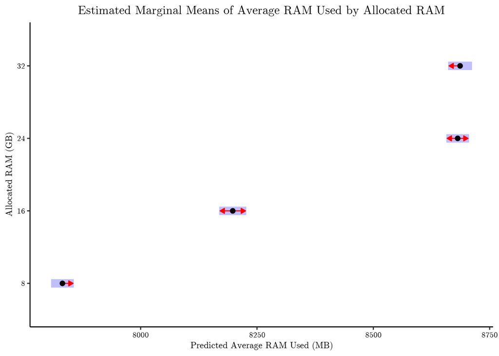

```r
plot(emm_ram_used, comparisons = TRUE) +
  labs(
    title = "Estimated Marginal Means of Average RAM Used by Allocated RAM",
    x = "Predicted Average RAM Used (MB)",
    y = "Allocated RAM (GB)",
  )
```